# BDM Project

[*Anilcan* *Atik*](https://github.com/Anilcana)

[*Dost* *Karaahmetli*](https://github.com/karaahmetlid)

[*Kutay* *Akalin*](https://github.com/KutayAkalin)

[*Tunahan* *Kiliç*](https://github.com/tunahankilic)

January 06th, 2020

# About the Data and Project

We use the Yelp’s datasets which includes bussiness, review and users information. In this analyse, we worked on the “Charlotte” city. Firstly we want to find popular categories in Charlotte like restaurants, shopping centers, services etc. After that, we did sentiment analysis for selected restaurants based on their reviews. For sentiment analysis, “bing” method was used and described in the relevant sections. Finally, we displayed the some of these restaurants as map in “Charlotte Restaurant Locations”.

In the begining, our data contains over 6 million review. Working with these amount of data is too slow for processing and displaying. After we chose the our purpose in this project, we sliced and cleaned our data before the summarise and visualize section. Preprocessing codes of sentiment analyse and map view displayed in the chunks respectively. Our data is Yelp Open Dataset, in JSON format, obtained directly from Yelp Website. More information on the dataset can be procured from the main dataset documentation page. It is an extensive data consisting of user/business information, reviews, votes, and much more. Thus, we are confident that we would be able to make rich analysis and interesting inferences while working on this abundant data.

Some Facts About the Dataset:

• 3.6 gigabytes compressed; 8.69 gigabytes uncompressed

• 1 .tar.gz file compressed, 6 .json files uncompressed

• 6,685,900 reviews

• 192,609 businesses

• 10 metropolitan areas

• 1,223,094 tips by 1,637,138 users

• Over 1.2 million business attributes like hours, parking, availability, and ambience

• Aggregated check-ins over time for each of the 192,609 businesses

The dataset consists of six files - business, tips, reviews, users, check-ins and photos. Each file is composed of a single object type, one json-object per-line. For the purposes of this project, we will be working with 3 of these - business, user and reviews.

## Acquire and Import Data

We acuired the data using PostgreSQL and made preliminary querying using the “sql magic”. We’ve done this process on Jupyter Notebook. You can access the work from the below link:

### [Acquire, import, query of the Yelp Dataset](https://karaahmetlid.github.io/mef03-karaahmetlid/Yelp/yelpdb.html)

## Reading Data

```r
review <- fread("C:/Users/dostk/Downloads/review_charlotte.csv")
business <- fread("C:/Users/dostk/Downloads/Yelp/yelp_academic_dataset_business_restaurants.csv")
```

```r
glimpse(review)
```

```
## Observations: 309,533
## Variables: 10
## $ V1          <chr> "1", "2", "3", "4", "5", "6", "7", "8", "9", "10", "11", …
## $ business_id <chr> "gnKjwL_1w79qoiV3IC_xQQ", "gnKjwL_1w79qoiV3IC_xQQ", "gnKj…
## $ review_id   <chr> "F7POrJsNbhu493DSTMPXjw", "c-6aA9Bd7JxpmMroRoas9A", "P_MV…
## $ user_id     <chr> "nsS4oDfOsl20QdWc6XcOkw", "bK4Y_GZUoAUTXIrmeEUGYw", "sbbB…
## $ stars.y     <chr> "2", "4", "2", "5", "4", "5", "5", "5", "3", "5", "4", "5…
## $ date        <chr> "2014-02-24 02:51:56", "2014-07-13 20:28:18", "2018-05-09…
## $ text        <chr> "Husband was craving Chicken Teriyaki & gyoza, so we foun…
## $ useful      <chr> "1", "0", "1", "4", "0", "11", "4", "0", "0", "3", "0", "…
## $ funny       <chr> "0", "0", "0", "2", "0", "0", "0", "0", "0", "1", "0", "0…
## $ cool        <chr> "0", "1", "0", "3", "0", "2", "0", "0", "0", "0", "0", "0…
```

```r
glimpse(business)
```

```
## Observations: 192,609
## Variables: 14
## $ business_id  <chr> "1SWheh84yJXfytovILXOAQ", "QXAEGFB4oINsVuTFxEYKFQ", "gnK…
## $ name         <chr> "Arizona Biltmore Golf Club", "Emerald Chinese Restauran…
## $ address      <chr> "2818 E Camino Acequia Drive", "30 Eglinton Avenue W", "…
## $ city         <chr> "Phoenix", "Mississauga", "Charlotte", "Goodyear", "Char…
## $ state        <chr> "AZ", "ON", "NC", "AZ", "NC", "ON", "AB", "NV", "AZ", "O…
## $ postal_code  <chr> "85016", "L5R 3E7", "28210", "85338", "28217", "L5V 0B1"…
## $ latitude     <dbl> 33.52214, 43.60550, 35.09256, 33.45561, 35.19001, 43.599…
## $ longitude    <dbl> -112.01848, -79.65229, -80.85913, -112.39560, -80.88722,…
## $ stars        <dbl> 3.0, 2.5, 4.0, 5.0, 4.0, 2.5, 3.5, 3.5, 5.0, 4.5, 2.0, 3…
## $ review_count <int> 5, 128, 170, 3, 4, 3, 7, 3, 8, 8, 5, 18, 9, 16, 7, 4, 5,…
## $ is_open      <int> 0, 1, 1, 1, 1, 1, 1, 1, 0, 1, 1, 1, 1, 1, 1, 1, 1, 0, 1,…
## $ attributes   <chr> "{'GoodForKids': 'False'}", "{'RestaurantsReservations':…
## $ categories   <chr> "Golf, Active Life", "Specialty Food, Restaurants, Dim S…
## $ hours        <chr> "", "{'Monday': '9:0-0:0', 'Tuesday': '9:0-0:0', 'Wednes…
```

## Most Popular 7 Categories in Charlotte

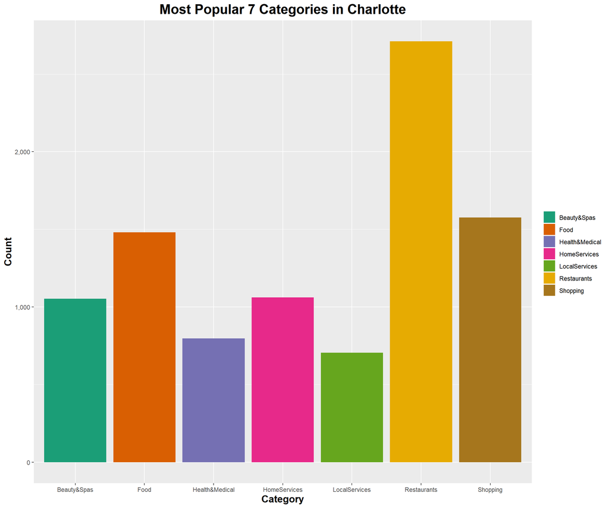

```r
char_cat <- business %>% filter(city == "Charlotte")
Category = str_split(char_cat$categories,",")
Category = as.data.frame(unlist(Category))
colnames(Category) = c("Category")
Category$Category=sapply(Category$Category, str_replace_all,pattern=" ",replacement="")

groups<-Category %>% group_by(Category) %>% summarise(Count = n()) %>% arrange(desc(Count)) %>% slice(1:7)

ggplot(data=groups, aes(x=Category, y=Count, fill=Category)) +
  geom_bar(stat="identity")+  labs(title = "Most Popular 7 Categories in Charlotte", x = "Category",
                                   y = "Count") +
  theme(title = element_text(size = 16, face = "bold"),
        plot.title = element_text(hjust = 0.5),
        axis.title.x = element_text(size = 14, face = "bold"),
        axis.title.y = element_text(size = 14, face = "bold"),
        legend.title = element_blank()) + scale_y_continuous(labels = comma) +
  scale_fill_brewer(palette="Dark2")
```

## Charlotte’s Most Reviewed Restaurants

```r
char_rest<-business %>% filter(city == "Charlotte" & grepl("Restaurant",categories)
                               & review_count>300)

char_rest<-char_rest %>% select("business_id","name","address","review_count","stars") %>% arrange(desc(review_count))

kable(head(char_rest,n=20L)) %>%
  kable_styling(bootstrap_options = c("striped", "hover", "condensed", "responsive"))
```

| business_id | name | address | review_count | stars |
| --- | --- | --- | --- | --- |
| RAh9WCQAuocM7hYM5_6tnw | The Cowfish Sushi Burger Bar | 4310 Sharon Rd, Ste X05 | 1572 | 4.0 |
| gG9z6zr_49LocyCTvSFg0w | Amélie’s French Bakery & Café | 2424 N Davidson St, Ste 102 | 1566 | 4.0 |
| WbJ1LRQdOuYYlRLyTkuuxw | Tupelo Honey | 1820 South Blvd | 1502 | 4.0 |
| RVQE2Z2uky4c0-njFQO66g | Midwood Smokehouse | 1401 Central Ave | 1474 | 4.5 |
| T2tEMLpTeSMxLKpxwFdS3g | Cabo Fish Taco | 3201 N Davidson St | 1095 | 4.0 |
| 01fuY2NNscttoTxOYbuZXw | Pinky’s Westside Grill | 1600 W Morehead St | 991 | 4.0 |
| ALwAlxItASeEs2vYAeLXHA | Futo Buta | 222 Bland St | 941 | 4.0 |
| NFm869_w6cvVaWaNpAzjeA | Soul Gastrolounge | 1500-B Central Ave | 934 | 4.0 |
| aO1gAp41n8w8zpxTiHdLNA | Mert’s Heart & Soul | 214 N College St | 894 | 3.5 |
| sdYkVaTy7EJwUkO8Ie_qPg | Viva Chicken | 1617 Elizabeth Ave | 849 | 4.5 |
| mC39IrCp36QIVFRZIw9PTQ | Seoul Food Meat Company | 1400 S Church St, Ste A | 830 | 4.0 |
| DyOzNIeXUksPNLXYHnB-oQ | Sabor Latin Street Grill | 415 Hawthorne Ln | 765 | 4.5 |
| yMopev-RPxfEXgqkJOvCGA | Cajun Queen | 1800 E 7th St | 712 | 4.0 |
| 9dqdzRzjSfbnMvjUGqWBAw | Midnight Diner | 115 E Carson Blvd | 689 | 4.0 |
| hggVnGwA5042-ABxqeJX-A | Good Food on Montford | 1701 Montford Dr | 671 | 4.5 |
| D2ojX9bvE0_-aIj9BhdZZA | 300 East | 300 East Blvd | 649 | 4.0 |
| gChmBjLSe3qa8rzEngoDLQ | Fahrenheit | 222 S Caldwell St | 647 | 3.0 |
| ADgacmZ-qXrSOhMfU6bmTA | 5Church | 127 N Tryon St, Ste 8 | 639 | 3.5 |
| bzbNGyrTwWHAgg1CqkSgeg | Terrace Restaurants | 4625 Piedmont Row Dr, Ste 105 | 634 | 4.0 |
| QvxBnMcBPP1z_NAIYCqqdA | Haberdish | 3106 N Davidson St | 630 | 4.5 |

## The Cowfish Sushi Burger Bar

### Word Cloud of The Cowfish Sushi Burger Bar Reviews

For wordcloud display, we need to do preprocessing on the data. We extracted the words of each reviews and removed the words like popular engish words (stop words), numbers and spaces fof more meaningfull inside about the restaurant. This map give us the key words of restaurant which chose by our customers.

```r
cowfish_w <- review %>% filter(business_id == "RAh9WCQAuocM7hYM5_6tnw") %>% unnest_tokens(word, text) %>% select("word")

# Create a corpus
cowfish_w <- Corpus(VectorSource(cowfish_w))

# Data cleaning for meaningful words
cowfish_w<- cowfish_w %>%  tm_map(removeNumbers) %>%
  tm_map(removePunctuation) %>%
  tm_map(stripWhitespace)
cowfish_w <- tm_map(cowfish_w, content_transformer(tolower))
cowfish_w <- tm_map(cowfish_w, removeWords, stopwords("english"))
cowfish_w <- tm_map(cowfish_w, removeWords, c("restaurant","charlotte"))

dtm <- TermDocumentMatrix(cowfish_w)
matrix <- as.matrix(dtm)
cowfish_w <- sort(rowSums(matrix),decreasing=TRUE)
df <- data.frame(word = names(cowfish_w),freq=cowfish_w)
set.seed(1234)
wordcloud2(data=df, size=1.6, color='random-dark')
```

[interactive chart not shown]

### Sentiment Anlaysis of “Cowfish Sushi Burger Bar” Reviews

“Tidytext” package was used for sentiment analysis. You can find detail by clicking [here](https://www.tidytextmining.com/). We calculated the setiments by using “bing” method. In this method, each words of the text colums are extracted and analysed by their sentiment meanings. There will be two different sentiments; positive and negative. After found the sentiments, we decided to give 1 point for each positive word and -1 point for each negative word. Finally, we calculated the overall sentiment points of the reviews.

```r
cowfish_s <- review %>% filter(business_id == "RAh9WCQAuocM7hYM5_6tnw") %>%
  unnest_tokens(word, text) %>%
  inner_join(get_sentiments("bing"), by = "word") %>% mutate(Sentiment_Point=0)

for (i in (1:nrow(cowfish_s))){
  if (cowfish_s$sentiment[i] == "positive"){
    cowfish_s$Sentiment_Point[i] = 1

  }else{
    cowfish_s$Sentiment_Point[i] = -1
  }
}

cowfish_s<-cowfish_s %>% group_by(review_id) %>%summarise(Sentiment = sum(Sentiment_Point)) %>%
  left_join(review,by = "review_id")
glimpse(cowfish_s)
```

```
## Observations: 1,640
## Variables: 11
## $ review_id   <chr> "-63NpWyPPmOl6zIADyS7eg", "-9LG2e55GbOmt43ma_1zww", "-aTi…
## $ Sentiment   <dbl> 8, 2, 1, 8, 10, 4, 5, 8, -1, 5, 3, 6, 13, 3, 5, 5, 8, 0, …
## $ V1          <chr> "71066", "70719", "70612", "70137", "70600", "71402", "70…
## $ business_id <chr> "RAh9WCQAuocM7hYM5_6tnw", "RAh9WCQAuocM7hYM5_6tnw", "RAh9…
## $ user_id     <chr> "IdD1Z_PMqF0zUn3uZWSeAg", "KC85LeqWvfEhUpasA41Iaw", "-np6…
## $ stars.y     <chr> "5", "5", "4", "4", "5", "5", "5", "5", "2", "5", "5", "5…
## $ date        <chr> "2013-04-23 02:14:16", "2014-04-05 00:18:24", "2013-03-25…
## $ text        <chr> "Let me just say, this place may put a few pounds on you …
## $ useful      <chr> "6", "0", "0", "4", "1", "0", "1", "0", "0", "7", "0", "0…
## $ funny       <chr> "3", "0", "0", "1", "0", "1", "0", "0", "0", "1", "0", "0…
## $ cool        <chr> "4", "0", "0", "2", "0", "0", "0", "1", "0", "5", "0", "0…
```

### Negative 5 Reviews

```r
worst<-cowfish_s %>% arrange(Sentiment) %>% slice(1:5) %>% select("date","text","Sentiment")

kable(worst) %>%
  kable_styling(bootstrap_options = c("striped", "hover", "condensed", "responsive"))
```

| date | text | Sentiment |
| --- | --- | --- |
| 2015-12-30 04:00:04 | So I’ll admit that I got lured into this place with the thought of, “”Oh! That sounds interesting…“” The reality is that it is notable as little less than a forcibly novel approach to two overdone and… | -13 |
| 2018-04-29 02:57:02 | Been wanting to come here forever. Great food however….. Design of restaurant is weird kitchen and bathroom are hear each other. Unfortunately oil and water don’t mix I slipped on the way to ladies ro… | -8 |
| 2015-06-10 21:52:09 | Be careful!! I had lunch here last week and became very ill. 2 of the 3 people I went with also got sick. Really really sick… The news is reporting that they have sanitary problems but I think it migh… | -8 |
| 2018-05-05 12:36:47 | Been wanting to come here forever. Great food however….. Design of restaurant is weird kitchen and bathroom are hear each other. Unfortunately oil and water don’t mix I slipped on the way to ladies ro… | -8 |
| 2016-04-06 02:25:19 | Awful awful awful. You’d think that a restaurant at southpark mall would be a little better. Terrible, slow service weather you’re at the bar rail or a table. Food is not that great, I ordered burger … | -6 |

### Positive 5 Reviews

```r
best<-cowfish_s %>% arrange(desc(Sentiment)) %>% slice(1:5) %>% select("date","text","Sentiment")

kable(best) %>%
  kable_styling(bootstrap_options = c("striped", "hover", "condensed", "responsive"))
```

| date | text | Sentiment |
| --- | --- | --- |
| 2016-09-12 20:33:23 | Sushi and burgers prepared exactly the way you want? Yes, please! This concept seems a little confused at first glance but turns out to be pretty darned ingenious! Cowfish gets 4.5 stars (I’m rounding… | 43 |
| 2012-03-21 21:16:20 | Here is a GREAT Burger! First I’ll start at the beginning! Or at least the beginning of my first meal here! I was so hungry I wanted to order some food just so my brain would function well enough to o… | 41 |
| 2012-08-10 02:33:51 | Burgers? And sushi? In the same restaurant? Whoa - what an amazing concept! Seriously, this place just might be heaven. Or a very close, very busy facsimile. Either way, despite its flaws, I love the … | 36 |
| 2018-10-31 03:30:28 | Every single time I’ve been to The Cowfish it’s been a wonderful meal and a wonderful evening, but tonight was something special. A few months back my best friend Chris and I were lucky enough to be p… | 33 |
| 2016-11-12 17:31:35 | Okay wow. I have eaten here a ton and I forgot I had never written a review! My boyfriend and I simply love Cowfish! It is one of our favorite spots around Charlotte, and a plus for us is that it’s cl… | 33 |

### Most Used Negative Words

It is very important to find most used words in bad reviews. With analysing these words, businesses can define their lacks and they can eliminate these lacks for increase the customer satisfaction.

[figure not shown]

```r
bad_w <- cowfish_s %>%unnest_tokens(word, text) %>%
  inner_join(get_sentiments("bing"), by = "word") %>% filter(sentiment == "negative")
bad_w<-bad_w %>% group_by(word) %>% summarise(Count=n()) %>% arrange(desc(Count)) %>%  ungroup() %>%
  mutate(Word = reorder(word,Count)) %>% slice(1:10)

ggplot(bad_w, aes(x=Word, y=Count)) +
  geom_bar(stat="identity")+  labs(title = "Negative Words of Midwood Smokehouse", x = "Word",
                                   y = "Count") +
  theme(title = element_text(size = 12, face = "bold"),
        plot.title = element_text(hjust = 0.5),
        axis.title.x = element_text(size = 10, face = "bold"),
        axis.title.y = element_text(size = 10, face = "bold"),
        legend.title = element_blank()) + scale_y_continuous(labels = comma) +
  coord_flip()
```

## Midwood Smokehouse

### Word Cloud of The Midwood Smokehouse Reviews

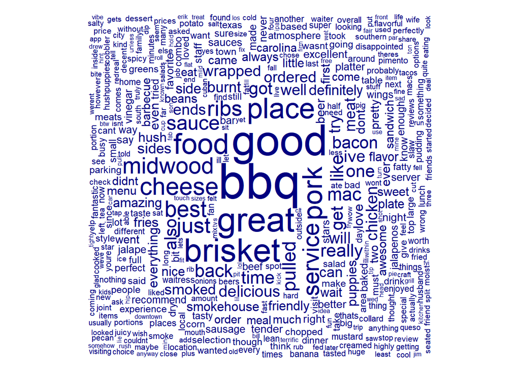

```r
midwood_w <- review %>% filter(business_id == "RVQE2Z2uky4c0-njFQO66g") %>% unnest_tokens(word, text) %>% select("word")

# Create a corpus
midwood_w <- Corpus(VectorSource(midwood_w))

# Data cleaning for meaningful words
midwood_w<- midwood_w %>%  tm_map(removeNumbers) %>%
  tm_map(removePunctuation) %>%
  tm_map(stripWhitespace)
midwood_w <- tm_map(midwood_w, content_transformer(tolower))
midwood_w <- tm_map(midwood_w, removeWords, stopwords("english"))
midwood_w <- tm_map(midwood_w, removeWords, c("restaurant","charlotte"))

dtm <- TermDocumentMatrix(midwood_w)
matrix <- as.matrix(dtm)
midwood_w <- sort(rowSums(matrix),decreasing=TRUE)
df1 <- data.frame(word = names(midwood_w),freq=midwood_w)

pal = brewer.pal(n=5,name="BuGn")
wordcloud(df1$word,df1$freq,random.order=F, random.color = T, rot.per=0.35, colors="navy")
```

### Sentiment Anlaysis of Midwood Smokehouse Reviews

```r
midwood_s <- review %>% filter(business_id == "RVQE2Z2uky4c0-njFQO66g") %>%
  unnest_tokens(word, text) %>%
  inner_join(get_sentiments("bing"), by = "word") %>% mutate(Sentiment_Point=0)

for (i in (1:nrow(midwood_s))){
  if (midwood_s$sentiment[i] == "positive"){
    midwood_s$Sentiment_Point[i] = 1

  }else{
    midwood_s$Sentiment_Point[i] = -1
  }
}

midwood_s<-midwood_s %>% group_by(review_id) %>%summarise(Sentiment = sum(Sentiment_Point)) %>%
  left_join(review,by = "review_id")
glimpse(midwood_s)
```

```
## Observations: 1,520
## Variables: 11
## $ review_id   <chr> "-0PwH2hD5MIcPwW3MyJ-Ew", "-4pI9otaOfe4gKdQ-vslQA", "-6iz…
## $ Sentiment   <dbl> 4, 7, 3, 15, 11, 8, 4, 2, 1, 6, 4, -2, 3, 6, 1, 2, 0, 8, …
## $ V1          <chr> "239177", "240054", "239875", "239176", "240328", "239672…
## $ business_id <chr> "RVQE2Z2uky4c0-njFQO66g", "RVQE2Z2uky4c0-njFQO66g", "RVQE…
## $ user_id     <chr> "m8T0repQUIK6WwW3d0-20Q", "kw4Q3Qfj_8WxjTNExSi1hw", "OLOF…
## $ stars.y     <chr> "4", "4", "3", "5", "4", "4", "5", "5", "5", "5", "5", "1…
## $ date        <chr> "2018-07-08 02:25:18", "2015-12-15 18:13:35", "2015-11-01…
## $ text        <chr> "First off - the sweet bbq sauce is something else. After…
## $ useful      <chr> "0", "0", "0", "0", "0", "1", "0", "0", "1", "0", "0", "0…
## $ funny       <chr> "0", "0", "0", "0", "0", "0", "0", "0", "0", "0", "0", "0…
## $ cool        <chr> "0", "1", "0", "0", "0", "0", "0", "0", "0", "0", "1", "0…
```

### Negative 5 Reviews

```r
worst<-midwood_s %>% arrange(Sentiment) %>% slice(1:5) %>% select("date","text","Sentiment")

kable(worst) %>%
  kable_styling(bootstrap_options = c("striped", "hover", "condensed", "responsive"))
```

| date | text | Sentiment |
| --- | --- | --- |
| 2016-05-15 04:09:04 | I was at first pleased with this place until I got sick from the food. I had the Briskit, which is supposed to be their best item. I am not one to get sick easily from food and when I do it is from ve… | -8 |
| 2017-01-28 02:06:03 | Let me just start by saying it’s really hard for me to place a 1 star yelp! I also believe you call and talk to the manager and hopefully they will correct issue before it has to go to this….now with … | -6 |
| 2018-07-12 00:53:35 | Absolutely terrible take out experience. The lady that took our order entered it in incorrectly but we didn’t know until we waited about 25 minutes for the food. The same lady then apologized for the … | -5 |
| 2014-06-08 15:09:49 | I went to mid wood smokehouse on a Saturday night. That was a mistake; the wait for a table wasn’t too bad - only 20 minutes but then it took an additional hour to actually get our food. It was extrem… | -5 |
| 2015-09-01 13:32:24 | Went to the Ballantyne location. Was disappointed there were very few healthy choices. Only two salad options to pick from! Seriously? That’s what is wrong with our country and why so many people are … | -5 |

### Positive 5 Reviews

```r
best<-midwood_s %>% arrange(desc(Sentiment)) %>% slice(1:5) %>% select("date","text","Sentiment")

kable(best) %>%
  kable_styling(bootstrap_options = c("striped", "hover", "condensed", "responsive"))
```

| date | text | Sentiment |
| --- | --- | --- |
| 2011-05-28 17:55:08 | I saw that a new BBQ place had opened up and had to go try it. I ate lunch there on a Saturday just a little before noon. The restaurant was nice, with an industrial feel to it, but very well done. It… | 33 |
| 2015-04-29 03:53:11 | Visited here Sunday Night. Parking, as everyone says, is a challenge, but not that bad. We had just come from spending the whole weekend hiking in Great Smokey Mountains NP, so we were HUNGRY. Got sea… | 31 |
| 2016-04-20 02:44:45 | 4.5 stars rounded up for good service and a great atmosphere and THE AMAZING PECAN COBBLER. I’ve heard much about Carolina BBQ and it’s goodness, so I decided to pick what seemed like one of the best … | 30 |
| 2015-10-05 17:11:39 | It’s no secret, Charlotte isn’t know for the best BBQ in the South. Meanwhile, Midwood does a great job at raising the bar in the Queen City. It’s the top BBQ joint in town, by a lot. Many will debate… | 28 |
| 2011-10-02 02:32:19 | Great ’Cue + Ambiance + Killer Service = Feeling REAAAL Good. (Bloated, but real good bloated!) After spending 3 years living in the Kansas City, eating some of the BEST BBQ in the country, it’s prett… | 26 |

### Most Used Negative Words

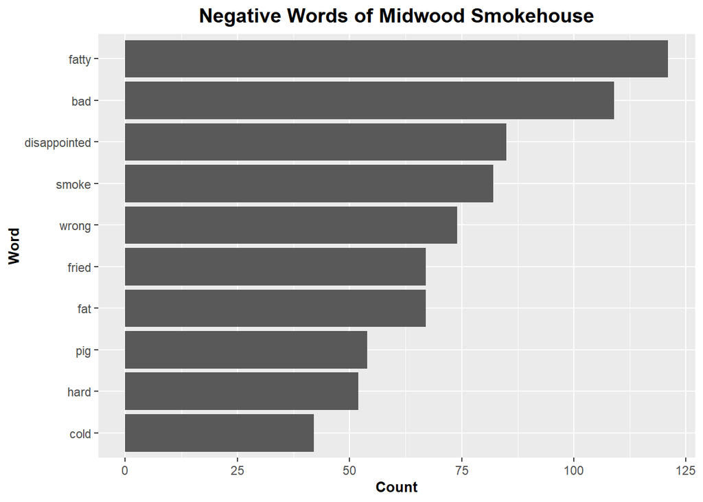

```r
bad_w <- midwood_s %>%unnest_tokens(word, text) %>%
  inner_join(get_sentiments("bing"), by = "word") %>% filter(sentiment == "negative")
bad_w<-bad_w %>% group_by(word) %>% summarise(Count=n()) %>% arrange(desc(Count)) %>%  ungroup() %>%
  mutate(Word = reorder(word,Count)) %>% slice(1:10)

ggplot(bad_w, aes(x=Word, y=Count)) +
  geom_bar(stat="identity")+  labs(title = "Negative Words of Midwood Smokehouse", x = "Word",
                                   y = "Count") +
  theme(title = element_text(size = 12, face = "bold"),
        plot.title = element_text(hjust = 0.5),
        axis.title.x = element_text(size = 10, face = "bold"),
        axis.title.y = element_text(size = 10, face = "bold"),
        legend.title = element_blank()) + scale_y_continuous(labels = comma) +
  coord_flip()
```

## Restaurant Maps: Charlotte, North Carolina

### **[Please follow this link for the restaurant maps](https://karaahmetlid.github.io/mef03-karaahmetlid/Yelp/maps.html)**